# Financial Economterics I

## Final project

### Summer Semester 2024/2025

#### Jan Sklenička, Sebastian Černý

This empirical project utilized artificial intelligence (AI) tools for assistance regarding coding and refining written content.

- Introduction
- Data Description
- Methodology
- Results
- Conclusion
- Appendix
  - Data Preparation
  - In-Sample fit
  - Out-of-Sample forcasting
  - Forecast Evaluation

## Introduction

Volatility forecasting plays a big role in modern financial econometrics and risk management. Accurate volatility estimates are essential for portfolio allocation, derivative pricing, Value-at-Risk (VaR) computation, and other risk management strategies. In recent years, the availability of high-frequency data has enabled the construction of realized measures of volatility, which serve as more informative proxies for true latent variance than traditional squared returns.

This project investigates the in-sample and out-of-sample performance of several popular volatility models, with a particular focus on their ability to forecast realized volatility of **Andeavor (ticker: ANDV)**. We compare traditional time-series models, such as the AR(1) and Heterogeneous Autoregressive (HAR) models, with more advanced extensions that incorporate realized semivariance, skewness, and kurtosis. In addition, we evaluate GARCH(1,1) and Realized GARCH models that account for volatility dynamics through conditional heteroskedasticity.

Our analysis is conducted on a dataset of daily financial returns and realized volatility constructed from high-frequency intraday data. The project involves:

- Estimating each model on an in-sample period and visually assessing fit
- Implementing both expanding and rolling window forecasting procedures
- Evaluating forecast accuracy using MAE, MSE, Diebold-Mariano tests, and Mincer-Zarnowitz regressions

By comparing a range of models from both the realized volatility regression and GARCH families, we aim to assess their relative strengths and weaknesses in predicting future volatility. In particular, we investigate whether incorporating asymmetries and higher-order moments leads to improved predictive performance, and how traditional GARCH models compare to realized-measure-based approaches.

## Data Description

The dataset used in this project contains daily financial market data, including:

- Log returns: $r_t$
- Realized volatility: $RV_t$
- Realized positive and negative semi-variances: $RV^+_t$, $RV^-_t$
- Realized skewness: $RS_t$
- Realized kurtosis: $RK_t$
- Date index: used to align and structure the time series

The realized volatility $RV_t$ is computed from high-frequency intraday data using returns, a common practice in volatility modeling. Specifically:

$$ RV_t = \sqrt{\sum_{i=1}^{n} r_{t,i}^2} $$

where $r_{t,i}$ is the $i$-th intraday return on day $t$.

To prepare the data for modeling, we transform the original `xts` object into a data frame and construct:

- **Lagged variables**: $RV_{t-1}$, $RV^+_{t-1}$, $RV^-_{t-1}$, $RS_{t-1}$, $RK_{t-1}$
- **Rolling averages** over 5 and 22 days to capture short- and medium-term volatility dynamics:

$$ RV5_t = \frac{1}{5} \sum_{j=1}^{5} RV_{t-j}, \quad RV22_t = \frac{1}{22} \sum_{j=1}^{22} RV_{t-j} $$

These features are used as inputs in models such as HAR, HAR-RSV, and HAR-RS-RK to forecast future realized volatility.

For GARCH-type models, daily log returns $r_t$ are scaled and used directly, and realized volatility $RV_t$ is also supplied to the Realized GARCH framework for joint modeling.

The sample period spans from early 2010 to 2016, with approximately 1500 daily observations. For forecasting purposes, an initial training window of 750 days is used, and the remaining ~750 days are used for out-of-sample evaluation.

##### Table 1: Descriptive statistics, code HERE

[output not shown]

##### Figure 1: Variable plots, code HERE

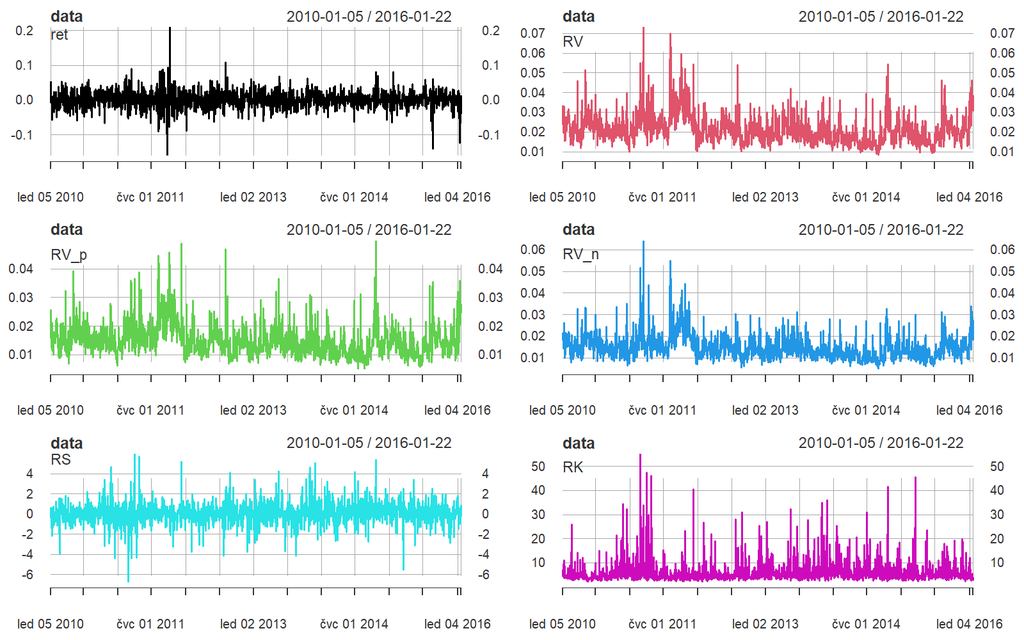

##### Figure 2: ACF and PACF for all variables, code HERE

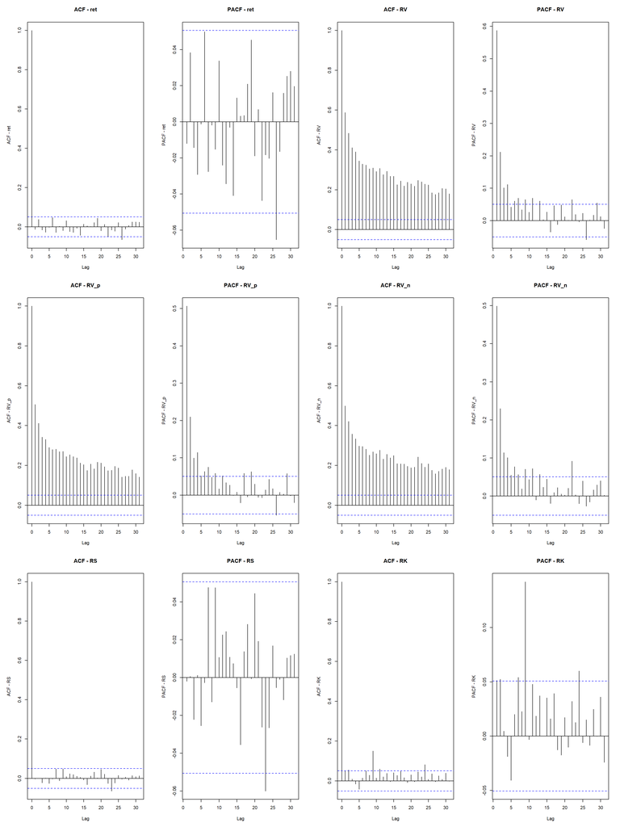

## Methodology

### In-Sample Modeling Framework

In this section, we estimate and compare various econometric models designed to explain and capture the dynamics of financial market volatility. Specifically, we model the realized volatility (RV) using autoregressive, heterogeneous autoregressive (HAR), and GARCH-type models. The goal is to assess how well each specification captures the persistence, memory, and asymmetry typically observed in financial volatility series.

#### 1. AR(1) Model for Realized Volatility

We begin with the basic autoregressive model of order 1, which serves as a benchmark:

$$ RV_t = \alpha_0 + \alpha_1 RV_{t-1} + \varepsilon_t $$

This model assumes that today's realized volatility is linearly dependent on yesterday's value, capturing short-term memory in volatility. While simple, it often performs surprisingly well in volatility forecasting.

#### 2. Heterogeneous Autoregressive (HAR) Model

To capture the persistence of volatility over different time horizons, we implement the HAR model:

$$ RV_t = \beta_0 + \beta_1 RV_{t-1} + \beta_2 RV^{(5)}_{t-1} + \beta_3 RV^{(22)}_{t-1} + \varepsilon_t $$

- **$RV_{t-1}$**: Lagged daily volatility
- **$RV^{(5)}_{t-1}$**: 5-day average of realized volatility (weekly component)
- **$RV^{(22)}_{t-1}$**: 22-day average of realized volatility (monthly component)

This structure captures the idea that market participants operate over different investment horizons.

#### 3. HAR with Realized Semivariance (HAR-RSV)

We enrich the HAR model by decomposing volatility into positive and negative components:

$$ RV_t = \beta_0 + \beta_1 RV_{p,t-1} + \beta_2 RV_{n,t-1} + \beta_3 RV^{(5)}_{t-1} + \beta_4 RV^{(22)}_{t-1} + \varepsilon_t $$

- **$RV_{p,t-1}$**: Lag of realized positive semivariance (from positive intraday returns)
- **$RV_{n,t-1}$**: Lag of realized negative semivariance (from negative intraday returns)

This allows the model to distinguish between volatility caused by good vs. bad news.

#### 4. HAR with Realized Skewness and Kurtosis (HAR-RSkew-RKurt)

To further enhance the explanatory power, we extend the HAR-RSV model with higher-order moments:

$$ RV_t = \beta_0 + \beta_1 RV_{t-1} + \beta_2 RV^{(5)}_{t-1} + \beta_3 RV^{(22)}_{t-1} + \beta_4 RS_{t-1} + \beta_5 RK_{t-1} + \varepsilon_t $$

- **$RS_{t-1}$**: Lag of realized skewness (captures asymmetry in return distribution)
- **$RK_{t-1}$**: Lag of realized kurtosis (captures tail risk or peakiness)

These additional variables reflect nonlinearities and potential jumps in volatility due to rare events or information shocks.

Each model is estimated using Ordinary Least Squares (OLS) on the full sample of data.

In addition to regression-based models, we estimate two key volatility models from the GARCH family. These models are designed to capture time-varying conditional volatility using past return innovations and volatility feedback mechanisms.

#### 5. GARCH(1,1) Model

The Generalized Autoregressive Conditional Heteroskedasticity (GARCH) model is a standard tool for modeling financial time series volatility. We use the GARCH(1,1) specification with a mean equation modeled as ARMA(0,0). (Returns were modeled as white noise because the ACF and PACF in **Figure 2** show no autocorrelation, this is also supported by the use of autoarima function in R):

$$ r_t = \mu + \varepsilon_t, \quad \varepsilon_t = z_t \sigma_t, \quad z_t \sim \mathcal{N}(0,1) $$$$ \sigma_t^2 = \omega + \alpha \varepsilon_{t-1}^2 + \beta \sigma_{t-1}^2 $$

- **$r_t$**: Return at time $t$
- **$\sigma_t^2$**: Conditional variance of returns
- **$\omega, \alpha, \beta$**: Model parameters, with $\alpha + \beta < 1$ for covariance stationarity

This model captures **volatility clustering**, where large shocks tend to be followed by large volatility. The use of ARMA(0,0) implies we assume the return series has no autocorrelation and focus purely on volatility dynamics.

#### 6. Realized GARCH Model (RealGARCH)

To improve upon the standard GARCH model by incorporating high-frequency information, we estimate the Realized GARCH model proposed by Hansen, Huang, and Shek (2012). It integrates realized volatility as a proxy for latent volatility and allows for a joint modeling framework.

##### Model specification (with ARMA(0,0) mean equation):

- **Mean equation**:

$$ r_t = \mu + \varepsilon_t, \quad \varepsilon_t \sim \mathcal{N}(0, \sigma_t^2) $$

- **Volatility (state) equation**:

$$ \log \sigma_t^2 = \omega + \beta \log \sigma_{t-1}^2 + \gamma \log RV_{t-1} $$

- **Measurement equation (linking realized and latent volatility)**:

$$ \log RV_t = \xi + \phi \log \sigma_t^2 + \tau z_t + u_t $$

Where:

- **$RV_t$**: Observed realized volatility from high-frequency data
- **$\sigma_t^2$**: Latent conditional variance
- **$z_t = \varepsilon_t / \sigma_t$**: Standardized return innovation
- **$u_t$**: Measurement error

The models produce forecasts of the conditional volatility $\hat{\sigma}_t$.

To evaluate in-sample fit, we compare these estimated conditional volatilities $\hat{\sigma}_t$ from GARCH models and estimated realized volatilities $\hat{RV_t}$ from AR/HAR models to the observed realized volatility $RV_t$, which is used as a nonparametric proxy for true latent variance. This comparison allows us to assess how closely each model tracks the actual evolution of volatility over time. We also plot the fitted values against the real values. This provides an initial diagnostic of each model’s ability to replicate volatility dynamics, including persistence, spikes, and clustering behavior.

### Forecasting Procedure

We implement two forecasting strategies: **Expanding Window** and **Rolling Window**, each producing 1-step-ahead forecasts from time $t$ to $t+1$.

#### 1. Expanding Window

- Initial training set: $\{1, 2, \dots, 750\}$
- For each $t = 750, 751, \dots, T-1$:
  - Estimate model using $\{1, 2, \dots, t\}$
  - Forecast next value:

    $$ \hat{RV}_{t+1} \quad \text{or} \quad \hat{\sigma}_{t+1}^2 $$
- Window grows as new data is added.

#### 2. Rolling Window

- Fixed training size: 750 observations
- For each $t = 750, 751, \dots, T-1$:
  - Estimate model using $\{t - 749, \dots, t\}$
  - Forecast next value:

    $$ \hat{RV}_{t+1} \quad \text{or} \quad \hat{\sigma}_{t+1}^2 $$
- Window shifts forward by one day at a time.

### Forecast Evaluation Metrics

To compare the out-of-sample forecast accuracy across models, we use the following evaluation tools:

#### 1. Mean Absolute Error (MAE)

$$ \text{MAE} = \frac{1}{n} \sum_{t=1}^{n} \left| \hat{RV}_t - RV_t \right| $$

Measures the average magnitude of forecast errors. Less sensitive to large errors than MSE.

#### 2. Mean Squared Error (MSE)

$$ \text{MSE} = \frac{1}{n} \sum_{t=1}^{n} \left( \hat{RV}_t - RV_t \right)^2 $$

Penalizes large forecast errors more heavily. Lower values indicate better predictive performance.

#### 3. Diebold-Mariano Test

The Diebold-Mariano (DM) test is used to statistically compare the forecast accuracy of two competing models.

- Let $d_t = L_1(e_{1t}) - L_2(e_{2t})$ be the difference in forecast losses (e.g., squared error)
- Null hypothesis: both models have equal forecast accuracy

Test statistic:

$$ DM = \frac{\bar{d}}{\sqrt{\widehat{\text{Var}}(\bar{d})}} \quad \text{where} \quad \bar{d} = \frac{1}{n} \sum_{t=1}^{n} d_t $$

A significant $p$-value implies one model outperforms the other.

#### 4. Mincer-Zarnowitz Regression

We assess forecast unbiasedness and efficiency by regressing realized volatility on the forecasts:

$$ RV_t = \alpha + \beta \hat{RV}_t + \varepsilon_t $$

Interpretation:

- $\alpha = 0$ and $\beta = 1$ indicate an unbiased forecast
- $R^2$ reflects how well the forecast explains actual volatility
- Statistically significant deviations from $\alpha = 0$ or $\beta = 1$ suggest bias or inefficiency

This regression is run for each model over the forecast period.

## Results

### In-sample fit

##### Figure 3: In-sample fit for all models, code HERE

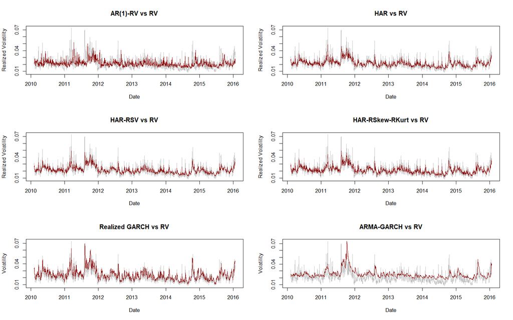

##### Figure 4: Comparison of Fitted Values (2010-2011), code HERE

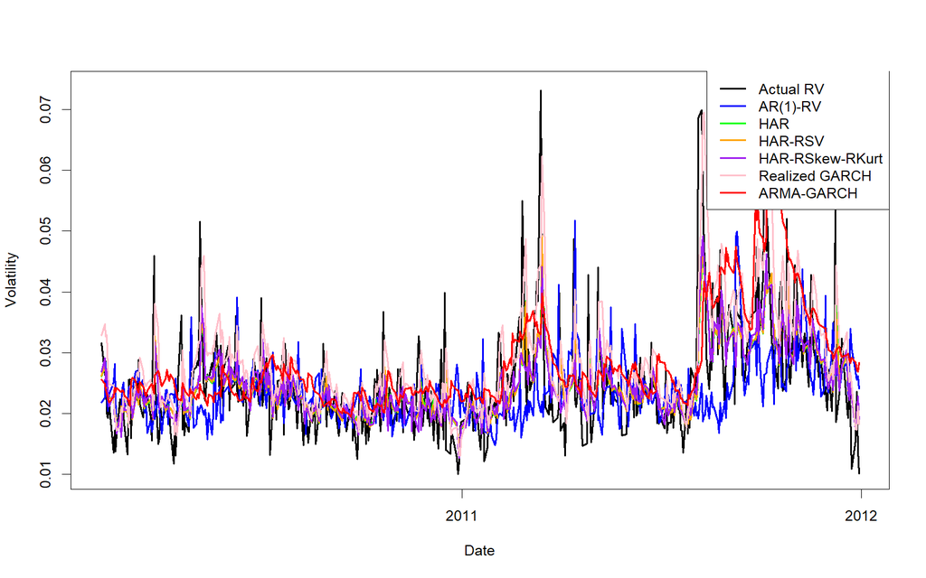

Visual inspection of the in-sample fitted values **(Figure 3)** shows that all models are able to replicate the dynamics of realized volatility to some extent. However, the Realized GARCH seems to be doing the best in terms of tracking the peaks and troughs more closely. On the other hand, standard GARCH appeared smoother and did not react well to volatility spikes, which is consistent with its latent conditional variance structure. While the HAR-RSkew-RKurt model seems to be slightly better than the other 3 autoregressive models, we could say that the differences between them are not that significant. A zoomed-in comparison of fitted values over 2010-2011 **(Figure 4)** confirmed these observations, with Realized GARCH capturing spikes with greater responsiveness.

### Out-of-sample forcasting

##### Figure 5: Expanding Window Forecasts vs Realized Volatility, code HERE

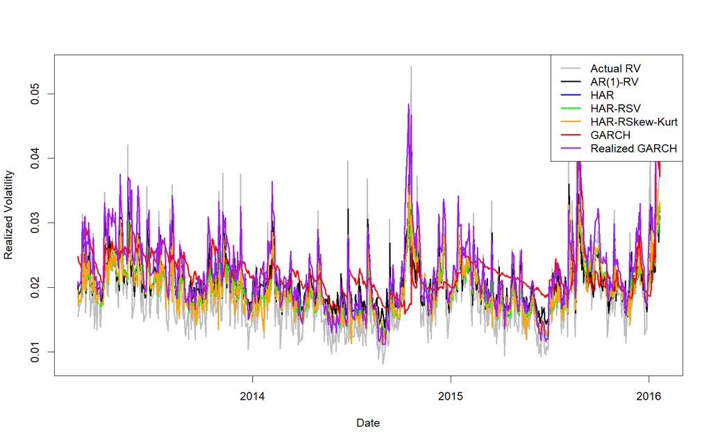

##### Figure 6: Rolling Window Forecasts vs Realized Volatility, code HERE

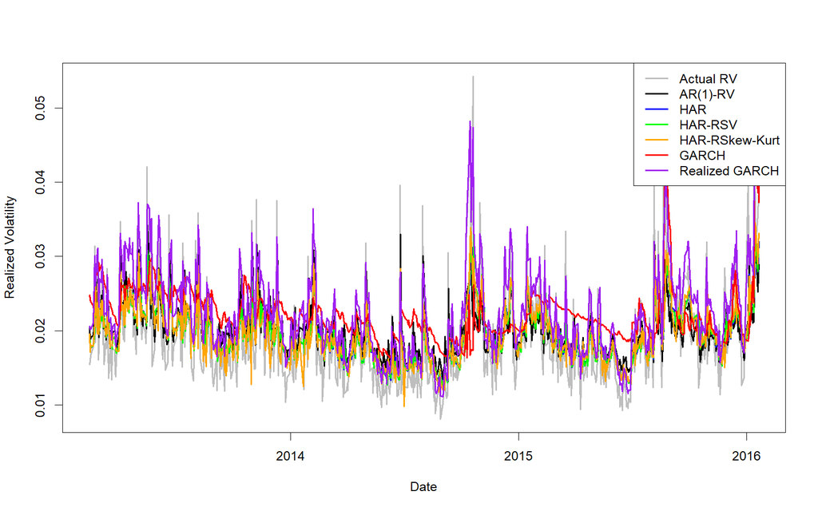

Regarding the forecasting performance, it was evaluated using both expanding and rolling window strategies explained in the **Methodology** section. **Figures 5 and 6** show forecast paths from all models compared to realized volatility. Again, Realized GARCH visually appeared to follow the true volatility most closely, especially during high-volatility periods. Additionally, GARCH remained overly smooth and lagging behind jumps.

##### Figure 7: Expanding vs Rolling Window Forecasts, code HERE

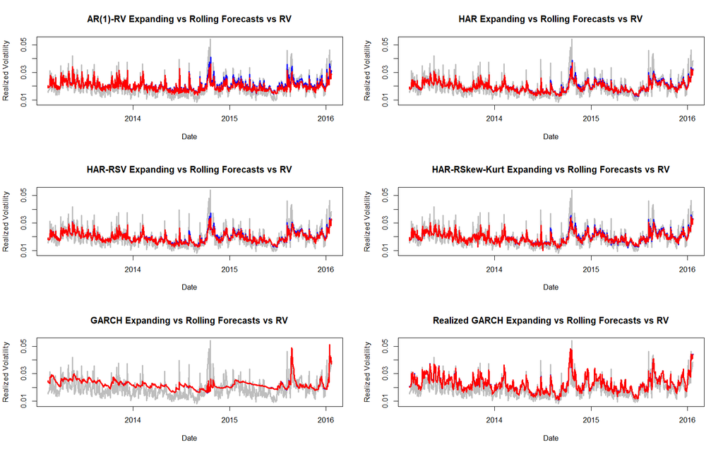

Comparing expanding and rolling windows **Figure 7**, we see that rolling windows provide more reactive forecasts, while expanding windows give us smoother predictions. This is typical and highlights the difference between stability for an expanding window and adaptability in the rolling window. However, we can see these differences after some time has passed - initially, both windows rely on almost the same data, so differences are minimal.

### Forecast evaluation

##### Figure 8: Expanding vs Rolling Window Forecasts Errors, code HERE

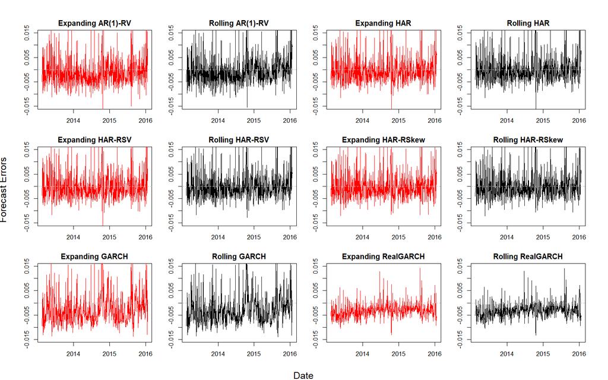

##### Table 2: MAE and MSE metrics, code HERE

| Model | MAE Expanding | MAE Rolling | MSE Expanding | MSE Rolling |
| --- | --- | --- | --- | --- |
| AR(1)-RV | 43.5 | 42.7 | 0.322 | 0.322 |
| HAR | 39.4 | 39.1 | 0.291 | 0.293 |
| HAR-RSV | 39.4 | 39.0 | 0.289 | 0.289 |
| HAR-RSkew-Kurt | 38.4 | 38.3 | 0.278 | 0.280 |
| GARCH | 54.5 | 54.3 | 0.455 | 0.448 |
| Realized GARCH | 36.9 | 36.9 | 0.184 | 0.185 |

The numerical results in **Table 2** (MAE and MSE metrics) clearly indicate that Realized GARCH outperforms all other models in both expanding and rolling windows, achieving the lowest forecast errors. Followed by HAR-type models and GARCH, again showing its poor performance. We can see that the difference between rolling and expanding windows is nearly 0, suggesting that there is not a significant difference for our data in this manner.

##### Table 3: Expanding Window Diebold-Mariano Test Results (One-Sided), code HERE

| Model 1 | Model 2 | Alternative | p-value |
| --- | --- | --- | --- |
| AR(1)-RV | HAR | greater | 0.4638 |
| AR(1)-RV | HAR-RSV | greater | 0.4168 |
| AR(1)-RV | HAR-RSkew | greater | 0.1804 |
| AR(1)-RV | GARCH | less | 0.01881 |
| AR(1)-RV | RealGARCH | greater | 0.001863 |
| HAR | HAR-RSV | greater | 0.08267 |
| HAR | HAR-RSkew | greater | 0.01345 |
| HAR | GARCH | less | 0.03457 |
| HAR | RealGARCH | greater | 0.0002858 |
| HAR-RSV | HAR-RSkew | greater | 0.01385 |
| HAR-RSV | GARCH | less | 0.03147 |
| HAR-RSV | RealGARCH | greater | 0.0003515 |
| HAR-RSkew | GARCH | less | 0.02161 |
| HAR-RSkew | RealGARCH | greater | 0.0004575 |
| GARCH | RealGARCH | greater | 0.002215 |

##### Table 4: Rolling Window Diebold-Mariano Test Results (One-Sided), code HERE

| Model 1 | Model 2 | Alternative | p-value |
| --- | --- | --- | --- |
| AR(1)-RV | HAR | greater | 0.3334 |
| AR(1)-RV | HAR-RSV | greater | 0.2508 |
| AR(1)-RV | HAR-RSkew | greater | 0.1346 |
| AR(1)-RV | GARCH | less | 0.04746 |
| AR(1)-RV | RealGARCH | greater | 0.002313 |
| HAR | HAR-RSV | greater | 0.03356 |
| HAR | HAR-RSkew | greater | 0.007274 |
| HAR | GARCH | less | 0.07467 |
| HAR | RealGARCH | greater | 0.0002173 |
| HAR-RSV | HAR-RSkew | greater | 0.01935 |
| HAR-RSV | GARCH | less | 0.06396 |
| HAR-RSV | RealGARCH | greater | 0.0003049 |
| HAR-RSkew | GARCH | less | 0.0475 |
| HAR-RSkew | RealGARCH | greater | 0.0003223 |
| GARCH | RealGARCH | greater | 0.00345 |

Diebold-Mariano test results in **Tables 3 and 4** further confirm the superiority of Realized GARCH. It significantly outperforms GARCH, AR, and also the best HAR variants in all pairwise comparisons. These findings are consistent across both forecast windows, suggesting robustness and also the indifference between the choice of window settings.

##### Table 5: Mincer-Zarnowitz Regression Summary for Forecast Evaluation, code HERE

| Window | Model | Intercept (α) | Intercept_t-stat | Slope (β) | Slope_t-stat |
| --- | --- | --- | --- | --- | --- |
| Expanding | AR | 0.0011 | 0.97 | 0.89 | -2.03 |
| Expanding | HAR | 0.00061 | 0.57 | 0.95 | -0.88 |
| Expanding | HAR_RSV | 0.00065 | 0.61 | 0.95 | -0.93 |
| Expanding | HAR_RSkew | 0.00095 | 0.97 | 0.94 | -1.24 |
| Expanding | GARCH | 0.0047 | 3.48 | 0.66 | -5.70 |
| Expanding | RealGARCH | -0.0029 | -6.78 | 0.99 | -0.07 |
| Rolling | AR | 0.0013 | 1.10 | 0.90 | -1.60 |
| Rolling | HAR | 0.00032 | 0.29 | 0.98 | -0.37 |
| Rolling | HAR_RSV | 0.00033 | 0.30 | 0.98 | -0.39 |
| Rolling | HAR_RSkew | 0.00061 | 0.60 | 0.97 | -0.65 |
| Rolling | GARCH | 0.0039 | 2.94 | 0.69 | -5.18 |
| Rolling | RealGARCH | -0.0028 | -6.68 | 0.98 | -0.09 |

The Mincer-Zarnowitz regression results in **Table 5** support the forecasting quality of Realized GARCH. Its slope coefficient is closest to the ideal value of 1 and a statistically insignificant slope t-statistic, indicating nearly unbiased forecasts. However, the intercept is significantly negative, suggesting a slight upward bias (model tends to overpredict realized volatility on average). On the other hand, the GARCH model has a significantly low slope and a highly significant positive intercept, both of which are statistically different from the ideal values. This further confirms that GARCH is not ideal for this task.

For AR and HAR-type models, the intercept and slope coefficients are generally close to desirable values, but none of them are statistically significant except for slope of AR model in expanding window, suggesting higher uncertainty in their forecast accuracy.

Overall, Realized GARCH stands out by having significant coefficient values closest to the desired ones, implying the most consistent and least biased forecasts.

## Conclusion

In this study, we compared several types of models to decide which one is the best for modelling and forecasting the volatility of the stock **ANDV**, starting from simple autoregressive frameworks to more advanced models. Specifically, we investigated the performance of AR(1) on realized volatility, the Heterogeneous Autoregressive model (HAR) and its other variants with realized semivariances and higher-order moments (HAR-RSV and HAR-RSkew-Rkurt), as well as parametric models including GARCH(1,1) and Realized GARCH. When evaluating the performance, we focused on both in-sample fit and out-of-sample forecasting accuracy, using many visual and statistical methods.

**(complete code used for this project is available in the Appendix below for better readibility)**

## Appendix

```r
install.packages("PerformanceAnalytics")
install.packages("xts")
install.packages("dplyr")
install.packages("tseries")
library(tseries)
install.packages("rugarch")
install.packages("HARModel")
library(rugarch)
library(HARModel)
library(PerformanceAnalytics)
library(xts)
library(dplyr)
install.packages("forecast")
library(forecast)
install.packages("zoo")
library(zoo)
```

### Data Preparation

```r
# Set the path to your zip file
zip_path <- "C:/Users/sklen/Desktop/Financial Ecox 1/data_project.zip"

# List files inside the zip
file_list <- unzip(zip_path, list = TRUE)

# Find the file named '32.RData'
target_file <- file_list$Name[grep("^32\\.RData$", file_list$Name, ignore.case = TRUE)]

if (length(target_file) == 0) {
  stop("File named '32.RData' not found in the ZIP.")
}

# Extract the file to the current working directory
unzip(zip_path, files = target_file)

# Load the RData file
load(target_file)

# Rename the loaded object to 'data'
data <- andv
```

##### Descriptive statistics code

```r
# Descriptive statistics and plots
head(data %>% as.data.frame())

round(t(suppressWarnings(table.Stats(data)[3:16,])),3)
```

A data.frame: 6 × 6

|  | ret <dbl> | RV <dbl> | RV_p <dbl> | RV_n <dbl> | RS <dbl> | RK <dbl> |
| --- | --- | --- | --- | --- | --- | --- |
| 2010-01-05 | 0.0529906681 | 0.02359778 | 0.01546248 | 0.01782601 | -0.3988564 | 4.089633 |
| 2010-01-06 | -0.0067286893 | 0.03332561 | 0.02559976 | 0.02133655 | 0.6295806 | 4.991274 |
| 2010-01-07 | 0.0080659739 | 0.02503208 | 0.01569764 | 0.01949845 | -1.4109342 | 9.439402 |
| 2010-01-08 | -0.0020142065 | 0.01968275 | 0.01339775 | 0.01441912 | -0.1986826 | 4.110652 |
| 2010-01-11 | -0.0006697669 | 0.02430118 | 0.01162964 | 0.02133773 | -2.1765652 | 10.978797 |
| 2010-01-12 | -0.0573120399 | 0.02776570 | 0.02122583 | 0.01789967 | 0.5016070 | 3.631974 |

A matrix: 6 × 14 of type dbl

|  | Minimum | Quartile 1 | Median | Arithmetic Mean | Geometric Mean | Quartile 3 | Maximum | SE Mean | LCL Mean (0.95) | UCL Mean (0.95) | Variance | Stdev | Skewness | Kurtosis |
| --- | --- | --- | --- | --- | --- | --- | --- | --- | --- | --- | --- | --- | --- | --- |
| ret | -0.159 | -0.014 | 0.001 | 0.001 | 0.001 | 0.016 | 0.210 | 0.001 | 0.000 | 0.003 | 0.001 | 0.026 | 0.098 | 5.012 |
| RV | 0.008 | 0.016 | 0.020 | 0.021 | 0.021 | 0.025 | 0.073 | 0.000 | 0.021 | 0.022 | 0.000 | 0.008 | 1.721 | 5.401 |
| RV_p | 0.005 | 0.011 | 0.014 | 0.015 | 0.015 | 0.018 | 0.050 | 0.000 | 0.015 | 0.015 | 0.000 | 0.006 | 1.688 | 4.860 |
| RV_n | 0.005 | 0.011 | 0.014 | 0.015 | 0.015 | 0.018 | 0.064 | 0.000 | 0.015 | 0.015 | 0.000 | 0.006 | 1.992 | 8.244 |
| RS | -6.747 | -0.527 | 0.040 | 0.053 | NaN | 0.622 | 5.953 | 0.029 | -0.004 | 0.109 | 1.246 | 1.116 | 0.104 | 4.427 |
| RK | 2.012 | 3.671 | 4.697 | 6.189 | 5.349 | 6.697 | 55.187 | 0.128 | 5.939 | 6.439 | 24.427 | 4.942 | 4.157 | 24.231 |

##### Variable plots code

```r
# Data behavior plots
png("DATA_plots.png", width = 1600, height = 1000, res = 150)
options(repr.plot.width = 14, repr.plot.height = 8)

par(mfrow=c(3,2))
plot.xts(data,multi.panel=1,yaxis.same=F)
dev.off()

cat("Plot saved. \n")
```

**png:** 2

```
Plot saved.
```

Code for testing stationarity of returns

```r
# Stationarity test for "Returns"
ret <- data[, "ret"]
suppressWarnings(adf_result <- adf.test(ret, alternative = "stationary"))

print(adf_result)
```

```
	Augmented Dickey-Fuller Test

data:  ret
Dickey-Fuller = -11.424, Lag order = 11, p-value = 0.01
alternative hypothesis: stationary
```

##### Code for ACF and PACF plots for all variables

```r
png("ACF_PACF.png", width = 3000, height = 4000, res = 200)  # Larger figure size and resolution
options(repr.plot.width = 20, repr.plot.height = 12)

data <- as.data.frame(data)
num_vars <- ncol(data)

# Adjust layout: ceil(num_vars/2) rows, 2 columns
par(mfrow = c(ceiling(num_vars)/2, 4), mar = c(5, 5, 4, 2) + 0.1)

for (var in colnames(data)) {
  acf(data[[var]], main = paste("ACF -", var), xlab = "Lag", ylab = paste("ACF -", var),
      na.action = na.pass)
  pacf(data[[var]], main = paste("PACF -", var), xlab = "Lag", ylab = paste("PACF -", var),
       na.action = na.pass)
}

dev.off()
cat("Plot saved.\n")
```

**png:** 2

```
Plot saved.
```

Code for getting the correct ARIMA order

```r
auto.arima(data$ret, ic= "aic", stepwise = FALSE, approximation = FALSE)
auto.arima(data$ret, ic= "bic", stepwise = FALSE, approximation = FALSE)
```

```
Series: data$ret
ARIMA(0,0,0) with non-zero mean

Coefficients:
        mean
      0.0013
s.e.  0.0007

sigma^2 = 0.0006644:  log likelihood = 3359.59
AIC=-6715.18   AICc=-6715.17   BIC=-6704.55
```

```
Series: data$ret
ARIMA(0,0,0) with zero mean

sigma^2 = 0.0006655:  log likelihood = 3357.81
AIC=-6713.62   AICc=-6713.62   BIC=-6708.31
```

### In-sample fit

```
Series: data$RV
ARIMA(1,0,0) with non-zero mean

Coefficients:
         ar1    mean
      0.5875  0.0214
s.e.  0.0209  0.0004

sigma^2 = 3.81e-05:  log likelihood = 5503.78
AIC=-11001.56   AICc=-11001.54   BIC=-10985.62

Training set error measures:
                       ME        RMSE         MAE       MPE    MAPE      MASE
Training set 2.910552e-06 0.006168708 0.004486218 -6.989467 21.6415 0.9050401
                   ACF1
Training set -0.1248311
```

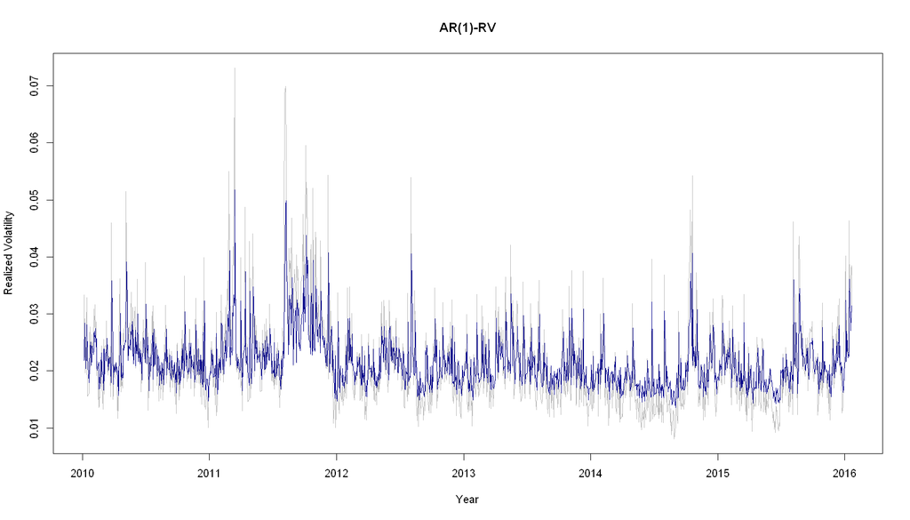

```r
# AR(1) fit for your data's RV
AR_RV <- Arima(data$RV, order = c(1,0,0))
summary(AR_RV)

# Plot actual vs fitted
plot(index(data$RV), data$RV, col="grey", main="AR(1)-RV", type="l",
     xlab="Year", ylab="Realized Volatility")
lines(index(data$RV), AR_RV$fitted, col="darkblue")
```

```r
df <- data %>%
  as.data.frame() %>%  # Convert the xts 'data' object to a data frame
  mutate(date = index(data)) %>%  # Add a 'date' column using the index of the xts object
  arrange(date) %>%  # Sorted by date

  # Create lagged variables and rolling averages for modeling
  mutate(
    RV_lag1 = lag(RV, 1),         # Lagged Realized Volatility
    RV_p_lag1 = lag(RV_p, 1),     # Lagged Positive Semi-Variance
    RV_n_lag1 = lag(RV_n, 1),     # Lagged Negative Semi-Variance

    RV5 = rollapply(RV, width=5, align="right", FUN=mean, fill=NA), # Rolling 5-day average of RV
    RV5_lag1 = lag(RV5, 1),       # Lagged 5-day rolling average

    RV22 = rollapply(RV, width=22, align="right", FUN=mean, fill=NA), # Rolling 22-day average of RV
    RV22_lag1 = lag(RV22, 1),     # Lagged 22-day rolling average

    RS_lag1 = lag(RS, 1),         # Lagged Realized Skewness
    RK_lag1 = lag(RK, 1)          # Lagged Realized Kurtosis
  ) %>%

  # Remove any rows where any lagged or rolling value is NA (due to lagging or rolling windows)
  filter(!is.na(RV_lag1) &
         !is.na(RV_p_lag1) &
         !is.na(RV_n_lag1) &
         !is.na(RV5_lag1) &
         !is.na(RV22_lag1) &
         !is.na(RS_lag1) &
         !is.na(RK_lag1))
```

```
Call:
lm(formula = RV ~ RV_lag1 + RV5_lag1 + RV22_lag1, data = df)

Residuals:
      Min        1Q    Median        3Q       Max
-0.019477 -0.003705 -0.001019  0.002538  0.039939

Coefficients:
             Estimate Std. Error t value Pr(>|t|)
(Intercept) 0.0030385  0.0007162   4.242 2.35e-05 ***
RV_lag1     0.3629488  0.0302293  12.007  < 2e-16 ***
RV5_lag1    0.2330519  0.0508335   4.585 4.93e-06 ***
RV22_lag1   0.2624881  0.0513805   5.109 3.67e-07 ***
---
Signif. codes:  0 '***' 0.001 '**' 0.01 '*' 0.05 '.' 0.1 ' ' 1

Residual standard error: 0.005939 on 1474 degrees of freedom
Multiple R-squared:  0.3986,	Adjusted R-squared:  0.3974
F-statistic: 325.7 on 3 and 1474 DF,  p-value: < 2.2e-16
```

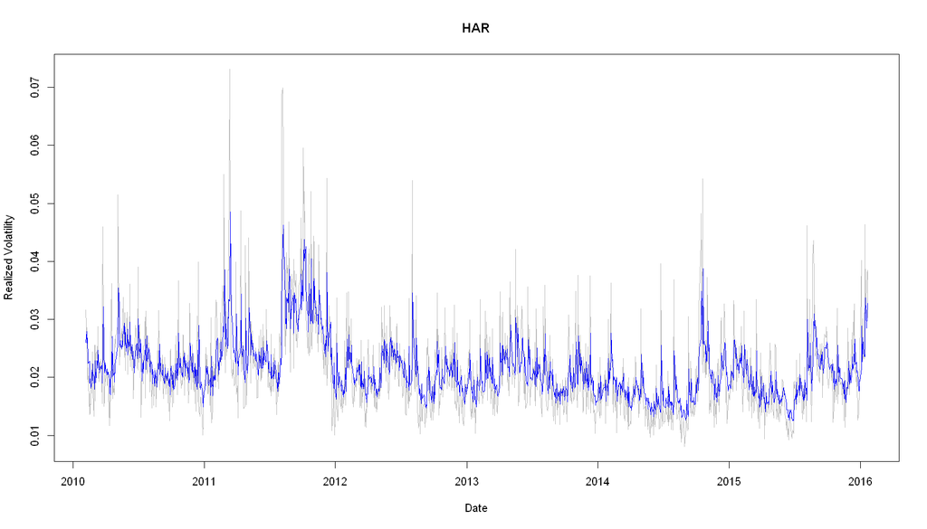

```r
# Fit the HAR-RV model
har_model <- lm(RV ~ RV_lag1 + RV5_lag1 + RV22_lag1, data = df)
summary(har_model)

# Plot actual vs fitted with date
plot(df$date, df$RV, col="grey", type="l", main="HAR", xlab="Date", ylab="Realized Volatility")
lines(df$date, har_model$fitted.values, col="blue")
```

```
Call:
lm(formula = RV ~ RV_p_lag1 + RV_n_lag1 + RV5_lag1 + RV22_lag1,
    data = df)

Residuals:
      Min        1Q    Median        3Q       Max
-0.017983 -0.003640 -0.000984  0.002512  0.041806

Coefficients:
             Estimate Std. Error t value Pr(>|t|)
(Intercept) 0.0030495  0.0007142   4.270 2.08e-05 ***
RV_p_lag1   0.2325739  0.0404712   5.747 1.10e-08 ***
RV_n_lag1   0.3083759  0.0386257   7.984 2.83e-15 ***
RV5_lag1    0.2215157  0.0509197   4.350 1.45e-05 ***
RV22_lag1   0.2580690  0.0512345   5.037 5.31e-07 ***
---
Signif. codes:  0 '***' 0.001 '**' 0.01 '*' 0.05 '.' 0.1 ' ' 1

Residual standard error: 0.005921 on 1473 degrees of freedom
Multiple R-squared:  0.4027,	Adjusted R-squared:  0.4011
F-statistic: 248.3 on 4 and 1473 DF,  p-value: < 2.2e-16
```

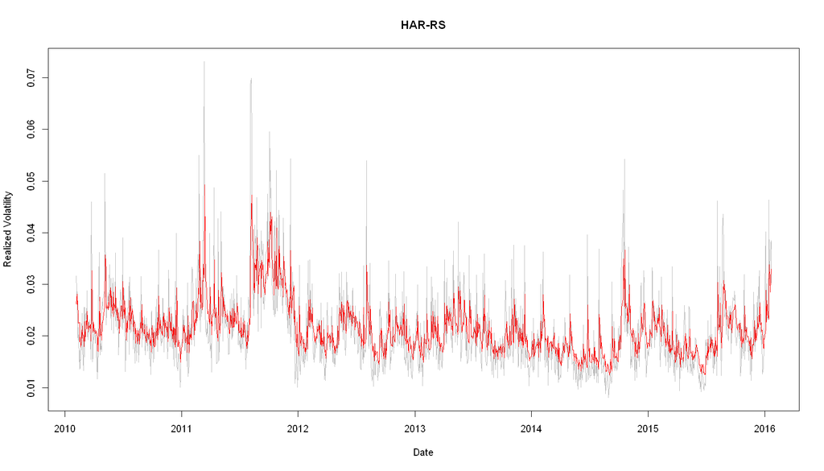

```r
# HAR-RS Model
har_rsv_model <- lm(RV ~ RV_p_lag1 + RV_n_lag1 + RV5_lag1 + RV22_lag1, data = df)
summary(har_rsv_model)

plot(df$date, df$RV, col="grey", type="l", main="HAR-RS", xlab="Date", ylab="Realized Volatility")
lines(df$date, har_rsv_model$fitted.values, col="red")
```

```
Call:
lm(formula = RV ~ RV_lag1 + RV5_lag1 + RV22_lag1 + RS_lag1 +
    RK_lag1, data = df)

Residuals:
      Min        1Q    Median        3Q       Max
-0.013299 -0.003705 -0.000897  0.002391  0.042336

Coefficients:
              Estimate Std. Error t value Pr(>|t|)
(Intercept)  4.835e-03  7.275e-04   6.646 4.24e-11 ***
RV_lag1      4.633e-01  3.163e-02  14.645  < 2e-16 ***
RV5_lag1     1.711e-01  5.011e-02   3.415 0.000656 ***
RV22_lag1    2.235e-01  5.031e-02   4.443 9.52e-06 ***
RS_lag1     -5.166e-05  1.350e-04  -0.383 0.701985
RK_lag1     -2.876e-04  3.274e-05  -8.782  < 2e-16 ***
---
Signif. codes:  0 '***' 0.001 '**' 0.01 '*' 0.05 '.' 0.1 ' ' 1

Residual standard error: 0.005792 on 1472 degrees of freedom
Multiple R-squared:  0.4289,	Adjusted R-squared:  0.4269
F-statistic: 221.1 on 5 and 1472 DF,  p-value: < 2.2e-16
```

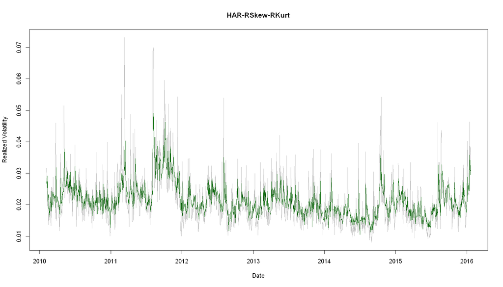

```r
# HAR-RSkew-RKurt Model
har_rsk_model <- lm(RV ~ RV_lag1 + RV5_lag1 + RV22_lag1 + RS_lag1 + RK_lag1, data = df)
summary(har_rsk_model)

plot(df$date, df$RV, col="grey", type="l", main="HAR-RSkew-RKurt", xlab="Date", ylab="Realized Volatility")
lines(df$date, har_rsk_model$fitted.values, col="darkgreen")
```

```
*---------------------------------*
*          GARCH Model Fit        *
*---------------------------------*

Conditional Variance Dynamics
-----------------------------------
GARCH Model	: realGARCH(1,1)
Mean Model	: ARFIMA(0,0,0)
Distribution	: norm

Optimal Parameters
------------------------------------
        Estimate  Std. Error  t value Pr(>|t|)
mu      0.001011    0.000547   1.8490 0.064461
omega   0.435484    0.226692   1.9210 0.054727
alpha1  1.000000    0.091164  10.9692 0.000000
beta1   0.541735    0.036932  14.6684 0.000000
eta11  -0.030427    0.006379  -4.7698 0.000002
eta21   0.026536    0.003874   6.8500 0.000000
delta   0.359674    0.022219  16.1875 0.000000
lambda  0.239972    0.004393  54.6293 0.000000
xi     -1.179793    0.167591  -7.0397 0.000000

Robust Standard Errors:
        Estimate  Std. Error  t value Pr(>|t|)
mu      0.001011    0.000527   1.9193 0.054947
omega   0.435484    0.329658   1.3210 0.186495
alpha1  1.000000    0.140559   7.1144 0.000000
beta1   0.541735    0.055932   9.6855 0.000000
eta11  -0.030427    0.006908  -4.4043 0.000011
eta21   0.026536    0.003653   7.2632 0.000000
delta   0.359674    0.027477  13.0902 0.000000
lambda  0.239972    0.005325  45.0692 0.000000
xi     -1.179793    0.209139  -5.6412 0.000000

LogLikelihood : 3548.6

Information Criteria
------------------------------------

```

[output cut: 51 more lines]

```
Negative Sign Bias   1.189 0.23451
Positive Sign Bias   2.171 0.03008  **
Joint Effect         6.128 0.10554


Adjusted Pearson Goodness-of-Fit Test:
------------------------------------
  group statistic p-value(g-1)
1    20     17.33      0.56730
2    30     28.32      0.50086
3    40     40.96      0.38454
4    50     62.67      0.09082


Elapsed time : 2.727723
```

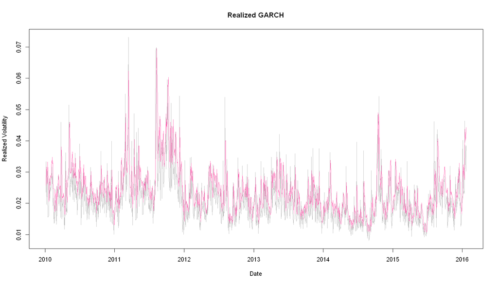

```r
# Define the Realized GARCH(1,1) specification
real_garch_spec <- ugarchspec(
  variance.model = list(
    model = "realGARCH",      # Use Realized GARCH
    garchOrder = c(1, 1)      # GARCH(1,1) order
  ),
  mean.model = list(
    armaOrder = c(0, 0),      # No ARMA in the mean
    include.mean = TRUE       # Include constant mean
  )
)

# Fit the model using returns and realized volatility (RV)
real_garch_fit <- ugarchfit(
  spec = real_garch_spec,
  data = data$ret,
  solver = "hybrid",
  realizedVol = data$RV
)

# Show model summary
print(real_garch_fit)

# Plot actual vs fitted volatility
plot(index(data$RV), data$RV, col="grey", type="l", main="Realized GARCH",
     xlab="Date", ylab="Realized Volatility")
lines(index(data$RV), real_garch_fit@fit$sigma, col="#FF69B4")
```

```r
p_max <- 3
q_max <- 3

aic_values <- matrix(NA, nrow = p_max + 1, ncol = q_max + 1)
bic_values <- matrix(NA, nrow = p_max + 1, ncol = q_max + 1)
results <- list()

for (p in 0:p_max) {
  for (q in 0:q_max) {
    spec <- ugarchspec(
      variance.model = list(model = "sGARCH", garchOrder = c(p, q)),
      mean.model = list(armaOrder = c(0, 0), include.mean = TRUE)
    )
    fit <- tryCatch(
      ugarchfit(spec = spec, data = data$ret, solver = "hybrid"),
      error = function(e) NULL,
      warning = function(w) NULL
    )
    if (!is.null(fit)) {
      ic <- tryCatch(
        infocriteria(fit),
        error = function(e) rep(NA, 4)
      )
      aic_values[p+1, q+1] <- ic[1]  # AIC
      bic_values[p+1, q+1] <- ic[2]  # BIC
      results[[paste0("GARCH(", p, ",", q, ")")]] <- fit
    } else {
    }
  }
}

# Find the best models
best_aic <- which(aic_values == min(aic_values, na.rm=TRUE), arr.ind=TRUE)
best_bic <- which(bic_values == min(bic_values, na.rm=TRUE), arr.ind=TRUE)

cat("Best model by AIC: GARCH(", best_aic[1]-1, ",", best_aic[2]-1, ")\n")
cat("Best model by BIC: GARCH(", best_bic[1]-1, ",", best_bic[2]-1, ")\n")
```

```
Best model by AIC: GARCH( 1 , 1 )
Best model by BIC: GARCH( 1 , 1 )
```

```
*---------------------------------*
*          GARCH Model Fit        *
*---------------------------------*

Conditional Variance Dynamics
-----------------------------------
GARCH Model	: sGARCH(1,1)
Mean Model	: ARFIMA(0,0,0)
Distribution	: norm

Optimal Parameters
------------------------------------
        Estimate  Std. Error  t value Pr(>|t|)
mu      0.001128    0.000602   1.8754 0.060733
omega   0.000026    0.000009   2.8917 0.003831
alpha1  0.075431    0.017188   4.3886 0.000011
beta1   0.886481    0.026011  34.0804 0.000000

Robust Standard Errors:
        Estimate  Std. Error  t value Pr(>|t|)
mu      0.001128    0.000632   1.7860 0.074106
omega   0.000026    0.000016   1.6373 0.101560
alpha1  0.075431    0.025374   2.9728 0.002951
beta1   0.886481    0.043204  20.5186 0.000000

LogLikelihood : 3438.737

Information Criteria
------------------------------------

Akaike       -4.5796
Bayes        -4.5655
Shibata      -4.5797
Hannan-Quinn -4.5744

Weighted Ljung-Box Test on Standardized Residuals
------------------------------------
                        statistic p-value
Lag[1]                   0.008743  0.9255
Lag[2*(p+q)+(p+q)-1][2]  1.309368  0.4079
```

[output cut: 36 more lines]

```
Negative Sign Bias   2.329 0.01999  **
Positive Sign Bias   1.305 0.19211
Joint Effect         7.872 0.04873  **


Adjusted Pearson Goodness-of-Fit Test:
------------------------------------
  group statistic p-value(g-1)
1    20     26.03      0.12945
2    30     40.00      0.08394
3    40     45.17      0.22971
4    50     53.13      0.31801


Elapsed time : 0.2580359
```

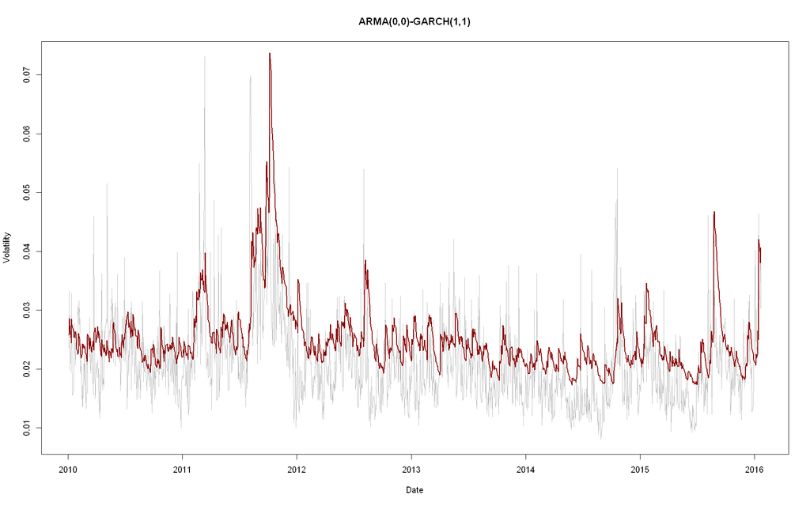

```r
# Specify the GARCH(1,1) model with constant mean
garch_spec <- ugarchspec(
  variance.model = list(model = "sGARCH", garchOrder = c(1, 1)),
  mean.model = list(armaOrder = c(0, 0), include.mean = TRUE)
)

# Fit the model to your returns
garch_fit <- ugarchfit(spec = garch_spec, data = data$ret)
print(garch_fit)

plot(index(data$RV), data$RV, col="grey", type="l",
     main="ARMA(0,0)-GARCH(1,1)", xlab="Date", ylab="Volatility")
lines(index(data$RV), garch_fit@fit$sigma, col="darkred", lwd=2)
```

##### In-sample fit for all models code

```r
# Check the difference in lengths
length_diff <- length(real_garch_fit@fit$sigma) - length(df$date)
aligned_dates <- df$date  # Align dates with your df length
aligned_sigma_real_garch <- tail(real_garch_fit@fit$sigma, length(aligned_dates))
aligned_sigma_garch <- tail(garch_fit@fit$sigma, length(aligned_dates))

# Create a list of models and their fitted values
models <- list(
  list(name = "AR(1)-RV",          fitted = AR_RV$fitted, data = df$RV,
                                   dates = df$date),
  list(name = "HAR",               fitted = har_model$fitted.values, data = df$RV,
                                   dates = df$date),
  list(name = "HAR-RSV",           fitted = har_rsv_model$fitted.values, data = df$RV,
                                   dates = df$date),
  list(name = "HAR-RSkew-RKurt",   fitted = har_rsk_model$fitted.values, data = df$RV,
                                   dates = df$date),
  list(name = "Realized GARCH",    fitted = aligned_sigma_real_garch, data = df$RV,
                                   dates = aligned_dates),
  list(name = "ARMA-GARCH",        fitted = aligned_sigma_garch, data = df$RV,
                                   dates = aligned_dates)
)
png("In_Sample_volatility_models_comparison.png", width = 1600, height = 1000, res = 150)
# Set up the plot grid: 3 rows, 2 columns
par(mfrow = c(3, 2))
options(repr.plot.width = 16, repr.plot.height = 10)

# Loop over models and create the plots
for (model in models) {
  zoo_data <- zoo(model$data, model$dates)
  zoo_fitted <- zoo(model$fitted, model$dates)

  # Determine y-axis label based on the model name
  ylab_title <- ifelse(model$name %in% c("Realized GARCH", "ARMA-GARCH"),
                       "Volatility", "Realized Volatility")

  plot.zoo(cbind(zoo_data, zoo_fitted),
           plot.type = "single",
           col = c("grey", "darkred"),
           main = paste(model$name, "vs RV"),
           xlab = "Date",
           ylab = ylab_title)

}
# Close the PNG device
dev.off()

cat("Plot saved. \n")
```

**png:** 2

```
Plot saved.
```

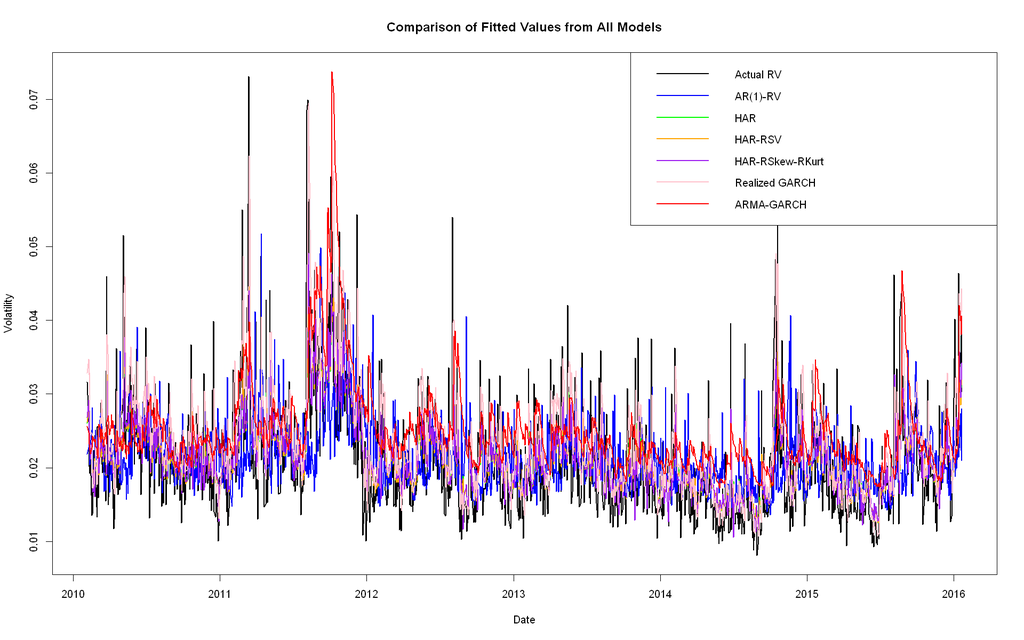

```r
# Prepare aligned GARCH series
aligned_dates <- df$date  # Keep aligned to df
aligned_sigma_real_garch <- tail(real_garch_fit@fit$sigma, length(aligned_dates))
aligned_sigma_garch <- tail(garch_fit@fit$sigma, length(aligned_dates))

# Create a list of models and their fitted values with correct dates
models <- list(
  list(name = "AR(1)-RV", fitted = AR_RV$fitted, dates = df$date),
  list(name = "HAR", fitted = har_model$fitted.values, dates = df$date),
  list(name = "HAR-RSV", fitted = har_rsv_model$fitted.values, dates = df$date),
  list(name = "HAR-RSkew-RKurt", fitted = har_rsk_model$fitted.values, dates = df$date),
  list(name = "Realized GARCH", fitted = aligned_sigma_real_garch, dates = aligned_dates),
  list(name = "ARMA-GARCH", fitted = aligned_sigma_garch, dates = aligned_dates)
)

# Initialize zoo list with actual RV
zoo_actual <- zoo(df$RV, df$date)
zoo_list <- list("Actual RV" = zoo_actual)

# Loop through models to add fitted values with correct dates
for (model in models) {
  zoo_fitted <- zoo(model$fitted, model$dates)
  zoo_list[[model$name]] <- zoo_fitted
}

# Merge and plot
combined <- do.call(merge, zoo_list)

colors <- c("black", "blue", "green", "orange", "purple", "pink", "red")

plot(combined, plot.type="single", col=colors, lwd=2,
     main="Comparison of Fitted Values from All Models", xlab="Date", ylab="Volatility")
legend("topright", legend=names(zoo_list), col=colors, lwd=2)
```

##### Code for plotting all models fit combined in two year window

```r
# Zoom to first two years
png("In_Sample_volatility_models_combined.png", width = 1600, height = 1000, res = 150)
start_date <- as.Date("2010-01-01")
end_date <- as.Date("2011-12-31")
combined_zoom <- window(combined, start=start_date, end=end_date)

# Plot zoomed-in view
plot(combined_zoom, plot.type="single", col=colors, lwd=2,
      xlab="Date", ylab="Volatility")
legend("topright", legend=names(zoo_list), col=colors, lwd=2)

dev.off()

cat("Plot saved. \n")
```

**png:** 2

```
Plot saved.
```

### Out-of-Sample forcasting

```r
expanding_window_forecast <- function(model_func, data, window_size,
                                      is_garch=FALSE, realizedVol=NULL) {
  n_forecast <- nrow(data) - window_size - 1

  if (is_garch) {
    # For GARCH models
    returns_xts <- xts(100 * data$ret, order.by = data$date)

    if (!is.null(realizedVol)) {
      realized_vol_xts <- xts(100 * realizedVol, order.by = data$date)
      roll <- ugarchroll(
        model_func,
        returns_xts,
        n.start = window_size,
        forecast.length = n_forecast,
        refit.every = 1,
        refit.window = "expanding",
        solver = "solnp",
        calculate.VaR = FALSE,
        keep.coef = TRUE,
        realizedVol = realized_vol_xts
      )
    } else {
      roll <- ugarchroll(
        model_func,
        returns_xts,
        n.start = window_size,
        forecast.length = n_forecast,
        refit.every = 1,
        refit.window = "expanding",
        solver = "solnp",
        calculate.VaR = FALSE,
        keep.coef = TRUE
      )
    }

    forecasts <- xts(roll@forecast$density[,"Sigma"] / 100,
                     order.by = as.Date(rownames(roll@forecast$density)))
    forecasts <- tail(forecasts, n_forecast)
    return(forecasts)

  } else {
    # For linear models (AR, HAR, HAR-RSV, HAR-RSkew-RKurt)
    forecasts <- vector("list", n_forecast)
    forecast_dates <- data$date[(window_size + 1):(window_size + n_forecast)]

    for (i in 1:n_forecast) {
      train_data <- data[1:(window_size + i - 1), ]

      # Recalculate RV5, RV22, RS, RK for the training window
      train_data <- train_data %>%
        arrange(date) %>%
        mutate(
          RV_lag1 = lag(RV, 1),
          RV_p_lag1 = lag(RV_p, 1),
          RV_n_lag1 = lag(RV_n, 1),
          RV5 = rollapply(RV, width=5, align="right", FUN=mean, fill=NA),
          RV5_lag1 = lag(RV5, 1),
          RV22 = rollapply(RV, width=22, align="right", FUN=mean, fill=NA),
          RV22_lag1 = lag(RV22, 1),
          RS_lag1 = lag(RS, 1),
          RK_lag1 = lag(RK, 1)
        ) %>%
        filter(!is.na(RV_lag1) & !is.na(RV5_lag1) & !is.na(RV22_lag1))

      newdata <- data[window_size + i, , drop=FALSE]

      fit <- tryCatch(model_func(train_data), error=function(e) NULL)
      forecasts[[i]] <- if (!is.null(fit)) predict(fit, newdata) else NA
    }

    forecast_zoo <- zoo(do.call(rbind, forecasts), order.by = forecast_dates)
    return(forecast_zoo)
  }
}
```

```r
# Set window size and automatically calculate forecast horizon
window_size <- 750  # Initial training window
n_forecast <- nrow(df) - window_size - 1  # Match seminar logic

# Model specifications
garch_spec <- ugarchspec(
  variance.model = list(model = "sGARCH", garchOrder = c(1,1)),
  mean.model = list(armaOrder = c(0,0), include.mean = TRUE)
)

realized_garch_spec <- ugarchspec(
  variance.model = list(model = "realGARCH", garchOrder = c(1,1)),
  mean.model = list(armaOrder = c(0,0))
)

# Forecasts (Expanding Window)
forecast_ar <- expanding_window_forecast(model_func_ar, df, window_size)
forecast_har <- expanding_window_forecast(model_func_har, df, window_size)
forecast_har_rsv <- expanding_window_forecast(model_func_har_rsv, df, window_size)
forecast_har_rskew <- expanding_window_forecast(model_func_har_rskew, df, window_size)
forecast_garch <- expanding_window_forecast(garch_spec, df, window_size, is_garch=TRUE)
forecast_real_garch <- expanding_window_forecast(realized_garch_spec, df,
                                                 window_size, is_garch=TRUE, realizedVol=df$RV)
```

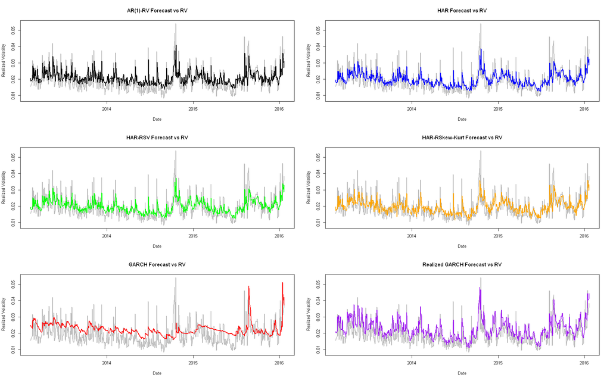

```r
# Define forecast dates
forecast_dates <- df$date[(window_size + 1):(window_size + n_forecast)]
actual_rv <- zoo(df$RV[(window_size + 1):(window_size + n_forecast)], order.by=forecast_dates)

# Function to plot each model forecast
plot_forecast <- function(actual, forecast, model_name, color="black") {
  forecast_zoo <- zoo(forecast, order.by=forecast_dates)
  plot(actual, col="grey", lwd=2, main=paste(model_name, "Forecast vs RV"),
       ylab=" Realized Volatility", xlab="Date")
  lines(forecast_zoo, col=color, lwd=2)

}
par(mfrow = c(3, 2))
options(repr.plot.width = 16, repr.plot.height = 10)
# Plot for each model
plot_forecast(actual_rv, forecast_ar, "AR(1)-RV", "black")
plot_forecast(actual_rv, forecast_har, "HAR", "blue")
plot_forecast(actual_rv, forecast_har_rsv, "HAR-RSV", "green")
plot_forecast(actual_rv, forecast_har_rskew, "HAR-RSkew-Kurt", "orange")
plot_forecast(actual_rv, forecast_garch, "GARCH", "red")
plot_forecast(actual_rv, forecast_real_garch, "Realized GARCH", "purple")
```

##### Expanding Window Forecasts vs Realized Volatility for all models

```r
# Define the dates for the forecast period (window_size+1 to window_size + n_forecast)
forecast_dates <- df$date[(window_size + 1):(window_size + n_forecast)]

# Create zoo objects for actual RV and forecasts
zoo_actual <- zoo(df$RV[(window_size + 1):(window_size + n_forecast)], order.by=forecast_dates)
zoo_ar <- zoo(forecast_ar, order.by=forecast_dates)
zoo_har <- zoo(forecast_har, order.by=forecast_dates)
zoo_har_rsv <- zoo(forecast_har_rsv, order.by=forecast_dates)
zoo_har_rskew <- zoo(forecast_har_rskew, order.by=forecast_dates)
zoo_garch <- zoo(forecast_garch, order.by=forecast_dates)
zoo_real_garch <- zoo(forecast_real_garch, order.by=forecast_dates)

# Combine all into one zoo object
combined <- merge(zoo_actual, zoo_ar, zoo_har, zoo_har_rsv, zoo_har_rskew,
                  zoo_garch, zoo_real_garch)
colnames(combined) <- c("Actual RV", "AR(1)-RV", "HAR", "HAR-RSV",
                        "HAR-RSkew-Kurt", "GARCH", "Realized GARCH")

png("Expanding Window Forecasts vs Realized Volatility.png", width = 1600,
    height = 1000, res = 150)
# Plot
plot(combined, plot.type="single", col=c("grey", "black", "blue", "green",
                                         "orange", "red", "purple"),
     lwd=2, xlab="Date", ylab="Realized Volatility")
legend("topright", legend=colnames(combined), col=c("grey", "black", "blue", "green",
                                                    "orange", "red", "purple"), lwd=2)
dev.off()

cat("Plot saved. \n")
```

**png:** 2

```
Plot saved.
```

```r
rolling_window_forecast <- function(model_func, data, window_size,
                                    is_garch=FALSE, realizedVol=NULL) {
  n_forecast <- nrow(data) - window_size - 1

  if (is_garch) {
    # For GARCH models
    returns_xts <- xts(100 * data$ret, order.by = data$date)

    if (!is.null(realizedVol)) {
      realized_vol_xts <- xts(100 * realizedVol, order.by = data$date)

      roll <- ugarchroll(
        model_func,
        returns_xts,
        n.start = window_size,
        forecast.length = n_forecast,
        refit.every = 1,
        refit.window = "moving",
        window.size = window_size,
        solver = "solnp",
        calculate.VaR = FALSE,
        keep.coef = TRUE,
        realizedVol = realized_vol_xts
      )

    } else {
      roll <- ugarchroll(
        model_func,
        returns_xts,
        n.start = window_size,
        forecast.length = n_forecast,
        refit.every = 1,
        refit.window = "moving",
        window.size = window_size,
        solver = "solnp",
        calculate.VaR = FALSE,
        keep.coef = TRUE
      )
    }

    forecasts <- xts(roll@forecast$density[,"Sigma"] / 100,
                     order.by = as.Date(rownames(roll@forecast$density)))
    forecasts <- tail(forecasts, n_forecast)  # Align with rolling window forecast length
    return(forecasts)

  } else {
    # For linear models (AR, HAR, HAR-RSV, HAR-RSkew-RKurt)
    forecasts <- vector("list", n_forecast)
    forecast_dates <- data$date[(window_size + 1):(window_size + n_forecast)]

    for (i in 1:n_forecast) {
      start_idx <- i
      end_idx <- window_size + i - 1
      train_data <- data[start_idx:end_idx, ]

      # Recalculate RV5, RV22, RS, RK for the training window
      train_data <- train_data %>%
        arrange(date) %>%
        mutate(
          RV_lag1 = lag(RV, 1),
          RV_p_lag1 = lag(RV_p, 1),
          RV_n_lag1 = lag(RV_n, 1),
          RV5 = rollapply(RV, width=5, align="right", FUN=mean, fill=NA),
          RV5_lag1 = lag(RV5, 1),
          RV22 = rollapply(RV, width=22, align="right", FUN=mean, fill=NA),
          RV22_lag1 = lag(RV22, 1),
          RS_lag1 = lag(RS, 1),
          RK_lag1 = lag(RK, 1)
        ) %>%
        filter(!is.na(RV_lag1) & !is.na(RV5_lag1) & !is.na(RV22_lag1))

      newdata <- data[window_size + i, , drop=FALSE]

      fit <- tryCatch(model_func(train_data), error=function(e) NULL)
      forecasts[[i]] <- if (!is.null(fit)) predict(fit, newdata) else NA
    }

    forecast_zoo <- zoo(do.call(rbind, forecasts), order.by = forecast_dates)
    return(forecast_zoo)
  }
}
```

```r
# Set window size and automatically calculate forecast horizon
window_size <- 750  # Rolling window size
n_forecast <- nrow(df) - window_size - 1  # Match seminar logic

# Model specifications
garch_spec <- ugarchspec(
  variance.model = list(model = "sGARCH", garchOrder = c(1,1)),
  mean.model = list(armaOrder = c(0,0), include.mean = TRUE)
)

realized_garch_spec <- ugarchspec(
  variance.model = list(model = "realGARCH", garchOrder = c(1,1)),
  mean.model = list(armaOrder = c(0,0))
)

# Forecasts using rolling window (aligned with updated rolling_window_forecast)
forecast_ar_roll <- rolling_window_forecast(model_func_ar, df, window_size)
forecast_har_roll <- rolling_window_forecast(model_func_har, df, window_size)
forecast_har_rsv_roll <- rolling_window_forecast(model_func_har_rsv, df, window_size)
forecast_har_rskew_roll <- rolling_window_forecast(model_func_har_rskew, df, window_size)
forecast_garch_roll <- rolling_window_forecast(garch_spec, df, window_size, is_garch=TRUE)
forecast_real_garch_roll <- rolling_window_forecast(realized_garch_spec, df, window_size, is_garch=TRUE, realizedVol=df$RV)
```

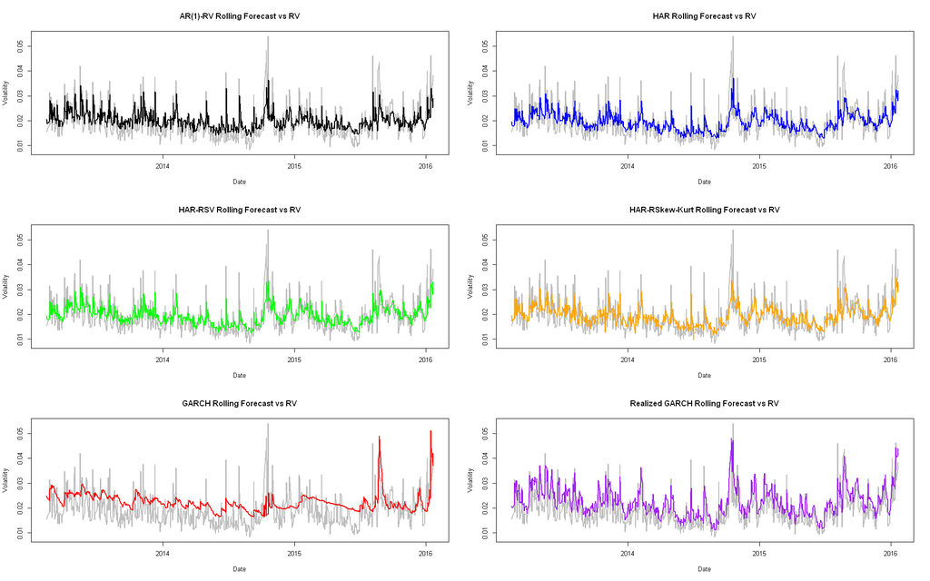

```r
# Define forecast dates for rolling window
forecast_dates_roll <- df$date[(window_size + 1):(window_size + n_forecast)]
actual_rv_roll <- zoo(df$RV[(window_size + 1):(window_size + n_forecast)], order.by=forecast_dates_roll)

# Function to plot each model forecast for rolling window
plot_forecast_roll <- function(actual, forecast, model_name, color="black") {
  forecast_zoo <- zoo(forecast, order.by=forecast_dates_roll)
  plot(actual, col="grey", lwd=2, main=paste(model_name, "Rolling Forecast vs RV"),
       ylab="Volatility", xlab="Date")
  lines(forecast_zoo, col=color, lwd=2)

}

par(mfrow = c(3, 2))
options(repr.plot.width = 16, repr.plot.height = 10)
# Plot for each model
plot_forecast_roll(actual_rv_roll, forecast_ar_roll, "AR(1)-RV", "black")
plot_forecast_roll(actual_rv_roll, forecast_har_roll, "HAR", "blue")
plot_forecast_roll(actual_rv_roll, forecast_har_rsv_roll, "HAR-RSV", "green")
plot_forecast_roll(actual_rv_roll, forecast_har_rskew_roll, "HAR-RSkew-Kurt", "orange")
plot_forecast_roll(actual_rv_roll, forecast_garch_roll, "GARCH", "red")
plot_forecast_roll(actual_rv_roll, forecast_real_garch_roll, "Realized GARCH", "purple")
```

##### Rolling Window Forecasts vs Realized Volatility for all models

```r
# Define the dates for the forecast period (window_size+1 to window_size + n_forecast)
forecast_dates_roll <- df$date[(window_size + 1):(window_size + n_forecast)]

# Create zoo objects for actual RV and forecasts
zoo_actual_roll <- zoo(df$RV[(window_size + 1):(window_size + n_forecast)], order.by=forecast_dates_roll)
zoo_ar_roll <- zoo(forecast_ar_roll, order.by=forecast_dates_roll)
zoo_har_roll <- zoo(forecast_har_roll, order.by=forecast_dates_roll)
zoo_har_rsv_roll <- zoo(forecast_har_rsv_roll, order.by=forecast_dates_roll)
zoo_har_rskew_roll <- zoo(forecast_har_rskew_roll, order.by=forecast_dates_roll)
zoo_garch_roll <- zoo(forecast_garch_roll, order.by=forecast_dates_roll)
zoo_real_garch_roll <- zoo(forecast_real_garch_roll, order.by=forecast_dates_roll)

# Combine all into one zoo object
combined_roll <- merge(zoo_actual_roll, zoo_ar_roll, zoo_har_roll, zoo_har_rsv_roll, zoo_har_rskew_roll, zoo_garch_roll, zoo_real_garch_roll)
colnames(combined_roll) <- c("Actual RV", "AR(1)-RV", "HAR", "HAR-RSV", "HAR-RSkew-Kurt", "GARCH", "Realized GARCH")
png("Rolling Window Forecasts vs Realized Volatility.png", width = 1600, height = 1000, res = 150)
# Plot
plot(combined_roll, plot.type="single", col=c("grey", "black", "blue", "green", "orange", "red", "purple"),
     lwd=2,  xlab="Date", ylab="Realized Volatility")
legend("topright", legend=colnames(combined_roll), col=c("grey", "black", "blue", "green", "orange", "red", "purple"), lwd=2)
dev.off()

cat("Plot saved. \n")
```

**png:** 2

```
Plot saved.
```

##### Combined graphs for all models

```r
# Combined forecast dates (assumed to be the same for both expanding and rolling)
forecast_dates <- df$date[(window_size + 1):(window_size + n_forecast)]
actual_rv <- zoo(df$RV[(window_size + 1):(window_size + n_forecast)], order.by=forecast_dates)

# Function to plot expanding vs rolling forecasts for a model
plot_combined_forecast <- function(actual, forecast_exp, forecast_roll, model_name, col_exp="blue", col_roll="red") {
  forecast_exp_zoo <- zoo(as.numeric(forecast_exp), order.by=forecast_dates)
  forecast_roll_zoo <- zoo(as.numeric(forecast_roll), order.by=forecast_dates)

  plot(actual, col="grey", lwd=2, main=paste(model_name, "Expanding vs Rolling Forecasts vs RV"),
       ylab="Realized Volatility", xlab="Date")
  lines(forecast_exp_zoo, col=col_exp, lwd=2)
  lines(forecast_roll_zoo, col=col_roll, lwd=2)

}
png("Expanding vs Rolling window forcasts.png", width = 1600, height = 1000, res = 150)
par(mfrow = c(3, 2))
options(repr.plot.width = 16, repr.plot.height = 10)
# Plot combined forecasts for each model
plot_combined_forecast(actual_rv, forecast_ar, forecast_ar_roll, "AR(1)-RV")
plot_combined_forecast(actual_rv, forecast_har, forecast_har_roll, "HAR")
plot_combined_forecast(actual_rv, forecast_har_rsv, forecast_har_rsv_roll, "HAR-RSV")
plot_combined_forecast(actual_rv, forecast_har_rskew, forecast_har_rskew_roll, "HAR-RSkew-Kurt")
plot_combined_forecast(actual_rv, forecast_garch, forecast_garch_roll, "GARCH")
plot_combined_forecast(actual_rv, forecast_real_garch, forecast_real_garch_roll, "Realized GARCH")
dev.off()

cat("Plot saved. \n")
```

**png:** 2

```
Plot saved.
```

### Forecast Evaluation

##### Code for plotting the errors

```r
# Extract the actual realized RV and corresponding dates
n_forecast <- length(forecast_ar)  # Adjust this based on the forecast vector length
forecast_dates <- df$date[(window_size + 1):(window_size + n_forecast)]
actual_rv <- df$RV[(window_size + 1):(window_size + n_forecast)]

# Define a helper function to compute zoo forecast errors
compute_errors_zoo <- function(forecast) {
  zoo(tail(actual_rv - as.numeric(forecast), n_forecast), order.by = forecast_dates)
}

# Create lists of forecast errors for both expanding and rolling
errors_expanding <- list(
  AR1_RV = compute_errors_zoo(forecast_ar),
  HAR = compute_errors_zoo(forecast_har),
  HAR_RSV = compute_errors_zoo(forecast_har_rsv),
  HAR_RSkew = compute_errors_zoo(forecast_har_rskew),
  GARCH = compute_errors_zoo(forecast_garch),
  RealGARCH = compute_errors_zoo(forecast_real_garch)
)

errors_rolling <- list(
  AR1_RV = compute_errors_zoo(forecast_ar_roll),
  HAR = compute_errors_zoo(forecast_har_roll),
  HAR_RSV = compute_errors_zoo(forecast_har_rsv_roll),
  HAR_RSkew = compute_errors_zoo(forecast_har_rskew_roll),
  GARCH = compute_errors_zoo(forecast_garch_roll),
  RealGARCH = compute_errors_zoo(forecast_real_garch_roll)
)

titles <- c("AR(1)-RV", "HAR", "HAR-RSV", "HAR-RSkew", "GARCH", "RealGARCH")
png("Forcast erros.png", width = 1600, height = 1000, res = 150)

par(mfrow = c(3, 4), mar = c(3, 3, 2, 1), oma = c(2, 2, 2, 2))
options(repr.plot.width = 25, repr.plot.height = 12)

exp_color <- "red"
roll_color <- "black"
ylim_range <- c(-0.015, 0.015)

# Loop over each model and plot expanding and rolling forecast errors
for (i in seq_along(titles)) {
  # Plot expanding
  plot.zoo(errors_expanding[[i]], col = exp_color, ylim = ylim_range,
           main = paste("Expanding", titles[i]), xlab = "", ylab = "")
  abline(h = 0, col = "gray", lty = 2)

  # Plot rolling
  plot.zoo(errors_rolling[[i]], col = roll_color, ylim = ylim_range,
           main = paste("Rolling", titles[i]), xlab = "", ylab = "")
  abline(h = 0, col = "gray", lty = 2)
}

mtext("Forecast Errors", side = 2, line = 1, outer = TRUE)
mtext("Date", side = 1, line = 1, outer = TRUE)
dev.off()

cat("Plot saved. \n")
```

**png:** 2

```
Plot saved.
```

##### MSE and MAE code

```r
# Correct forecast alignment
window_size <- 750  # Adjust as needed
n_forecast <- length(forecast_ar)

# Align dates and actual realized volatility (RV)
forecast_dates <- df$date[(window_size + 1):(window_size + n_forecast)]
actual_rv <- df$RV[(window_size + 1):(window_size + n_forecast)]
forecast_dates_zoo <- zoo(actual_rv, order.by = forecast_dates)

# Convert forecasts to numeric and align lengths
convert_forecast <- function(forecast) tail(as.numeric(forecast), n_forecast)

# Define aligned forecasts (Expanding)
exp_forecasts <- list(
  "AR(1)-RV" = convert_forecast(forecast_ar),
  "HAR" = convert_forecast(forecast_har),
  "HAR-RSV" = convert_forecast(forecast_har_rsv),
  "HAR-RSkew-Kurt" = convert_forecast(forecast_har_rskew),
  "GARCH" = convert_forecast(forecast_garch),
  "Realized GARCH" = convert_forecast(forecast_real_garch)
)

# Define aligned forecasts (Rolling)
roll_forecasts <- list(
  "AR(1)-RV" = convert_forecast(forecast_ar_roll),
  "HAR" = convert_forecast(forecast_har_roll),
  "HAR-RSV" = convert_forecast(forecast_har_rsv_roll),
  "HAR-RSkew-Kurt" = convert_forecast(forecast_har_rskew_roll),
  "GARCH" = convert_forecast(forecast_garch_roll),
  "Realized GARCH" = convert_forecast(forecast_real_garch_roll)
)

models <- names(exp_forecasts)

# Calculate MSE and MAE
calc_errors <- function(actual, forecast) {
  error <- actual - forecast
  mse <- mean(error^2, na.rm = TRUE)
  mae <- mean(abs(error), na.rm = TRUE)
  return(c(MSE = mse, MAE = mae))
}

error_metrics_exp <- 10000 * sapply(exp_forecasts, function(f) calc_errors(actual_rv, f))
error_metrics_roll <- 10000 * sapply(roll_forecasts, function(f) calc_errors(actual_rv, f))

# Create error dataframe (for easy viewing)
library(tibble)
error_df <- tibble(
  Model = rep(models, each=2),
  Metric = rep(c("MSE", "MAE"), times=length(models)),
  Expanding = as.numeric(error_metrics_exp),
  Rolling = as.numeric(error_metrics_roll)
)
suppressWarnings(print(error_df))

# Helper: Calculate squared errors for DM test
calc_mse <- function(actual, forecast) (actual - forecast)^2

mse_exp <- lapply(exp_forecasts, function(f) calc_mse(actual_rv, f))
mse_roll <- lapply(roll_forecasts, function(f) calc_mse(actual_rv, f))
```

```
# A tibble: 12 x 4
   Model          Metric Expanding Rolling
   <chr>          <chr>      <dbl>   <dbl>
 1 AR(1)-RV       MSE        0.322   0.322
 2 AR(1)-RV       MAE       43.5    42.7
 3 HAR            MSE        0.291   0.293
 4 HAR            MAE       39.4    39.1
 5 HAR-RSV        MSE        0.289   0.289
 6 HAR-RSV        MAE       39.4    39.0
 7 HAR-RSkew-Kurt MSE        0.278   0.280
 8 HAR-RSkew-Kurt MAE       38.4    38.3
 9 GARCH          MSE        0.455   0.448
10 GARCH          MAE       54.5    54.3
11 Realized GARCH MSE        0.184   0.185
12 Realized GARCH MAE       36.9    36.9
```

##### One sided DM test

```r
# Function to run Diebold-Mariano with ideal alternative
run_dm_test <- function(model_i, model_j, mse_list, models) {
  diff <- mean(mse_list[[model_i]]) - mean(mse_list[[model_j]])
  alternative <- ifelse(diff > 0, "greater", "less")
  cat("\nComparing", models[model_i], "vs", models[model_j], "- Alternative:", alternative, "\n")
  print(dm.test(mse_list[[model_i]], mse_list[[model_j]], alternative = alternative))
}

# Expanding Window
cat("\n--- Diebold-Mariano Tests (Expanding) - One-sided ---\n")
for (i in 1:(length(models)-1)) {
  for (j in (i+1):length(models)) {
    run_dm_test(i, j, mse_exp, models)
  }
}

# Rolling Window
cat("\n--- Diebold-Mariano Tests (Rolling) - One-sided ---\n")
for (i in 1:(length(models)-1)) {
  for (j in (i+1):length(models)) {
    run_dm_test(i, j, mse_roll, models)
  }
}
```

```
--- Diebold-Mariano Tests (Expanding) - One-sided ---

Comparing AR(1)-RV vs HAR - Alternative: greater

	Diebold-Mariano Test

data:  mse_list[[model_i]]mse_list[[model_j]]
DM = 0.090827, Forecast horizon = 1, Loss function power = 2, p-value =
0.4638
alternative hypothesis: greater


Comparing AR(1)-RV vs HAR-RSV - Alternative: greater

	Diebold-Mariano Test

data:  mse_list[[model_i]]mse_list[[model_j]]
DM = 0.21016, Forecast horizon = 1, Loss function power = 2, p-value =
0.4168
alternative hypothesis: greater


Comparing AR(1)-RV vs HAR-RSkew-Kurt - Alternative: greater

	Diebold-Mariano Test

data:  mse_list[[model_i]]mse_list[[model_j]]
DM = 0.91424, Forecast horizon = 1, Loss function power = 2, p-value =
0.1804
alternative hypothesis: greater


Comparing AR(1)-RV vs GARCH - Alternative: less

	Diebold-Mariano Test

data:  mse_list[[model_i]]mse_list[[model_j]]
DM = -2.0828, Forecast horizon = 1, Loss function power = 2, p-value =
0.01881
alternative hypothesis: less
```

[output cut: 247 more lines]

```

data:  mse_list[[model_i]]mse_list[[model_j]]
DM = 3.4271, Forecast horizon = 1, Loss function power = 2, p-value =
0.0003223
alternative hypothesis: greater


Comparing GARCH vs Realized GARCH - Alternative: greater

	Diebold-Mariano Test

data:  mse_list[[model_i]]mse_list[[model_j]]
DM = 2.7093, Forecast horizon = 1, Loss function power = 2, p-value =
0.00345
alternative hypothesis: greater
```

##### MZ regression

```r
# Set window size and align forecasts with actuals
window_size <- 750
n_forecast <- length(forecast_ar)

# Align indices for forecasts and actual realized volatility
aligned_index <- (window_size + 1):(window_size + n_forecast)
forecast_dates <- df$date[aligned_index]  # Dates for the forecast period
actual_rv <- df$RV[aligned_index]  # Actual realized volatility for forecast period

forecast_names <- c("AR", "HAR", "HAR_RSV", "HAR_RSkew", "GARCH", "RealGARCH")

# Expanding window forecasts
exp_forecasts <- setNames(
  lapply(list(forecast_ar, forecast_har, forecast_har_rsv, forecast_har_rskew, forecast_garch, forecast_real_garch),
         as.numeric),
  forecast_names
)

# Rolling window forecasts
roll_forecasts <- setNames(
  lapply(list(forecast_ar_roll, forecast_har_roll, forecast_har_rsv_roll, forecast_har_rskew_roll, forecast_garch_roll, forecast_real_garch_roll),
         as.numeric),
  forecast_names
)

# Define function to extract MZ regression statistics for each model
extract_mz_stats <- function(actual, forecast) {
  len <- min(length(actual), length(forecast))  # Ensure both vectors are the same length

  # Fit the MZ regression: actual = beta0 + beta1 * forecast + error
  fit <- lm(actual[1:len] ~ forecast[1:len])

  # Extract coefficient summary (estimates, standard errors, t-values)
  coefs <- summary(fit)$coefficients

  # Intercept estimate and its default t-statistic (H0: beta0=0)
  intercept_est <- coefs[1,1]
  intercept_t <- coefs[1,3]

  # Forecast slope estimate and standard error
  forecast_est <- coefs[2,1]
  forecast_se <- coefs[2,2]

  # Corrected t-statistic for testing H0: beta1 = 1
  forecast_t_corrected <- (forecast_est - 1) / forecast_se

  # Return a vector of estimates and t-stats
  return(c(Intercept=intercept_est, Intercept_t=intercept_t,
           Forecast=forecast_est, Forecast_t=forecast_t_corrected))
}

# Define a function to apply extract_mz_stats to each model in a list of forecasts
extract_forecast_stats <- function(forecast_list, window) {
  # Apply extract_mz_stats to each forecast in the list
  stats <- sapply(forecast_list, function(f) extract_mz_stats(actual_rv, f))

  # Transpose the results to have one row per model
  df <- as.data.frame(t(stats))

  df$Model <- rownames(df)
  df$Window <- window

  return(df)
}

# Extract MZ stats for both Expanding and Rolling forecasts
exp_df <- extract_forecast_stats(exp_forecasts, "Expanding")
roll_df <- extract_forecast_stats(roll_forecasts, "Rolling")


library(dplyr)
mz_summary <- bind_rows(exp_df, roll_df) %>%
  select(Window, Model, Intercept, Intercept_t, Forecast, Forecast_t)

print(mz_summary)
```

```
                  Window     Model     Intercept Intercept_t  Forecast
AR...1         Expanding        AR  0.0011140542   0.9743295 0.8889348
HAR...2        Expanding       HAR  0.0006066589   0.5695458 0.9532549
HAR_RSV...3    Expanding   HAR_RSV  0.0006458620   0.6117501 0.9510493
HAR_RSkew...4  Expanding HAR_RSkew  0.0009542696   0.9748663 0.9394731
GARCH...5      Expanding     GARCH  0.0046758913   3.4818134 0.6608079
RealGARCH...6  Expanding RealGARCH -0.0028642153  -6.7772549 0.9856365
AR...7           Rolling        AR  0.0013321269   1.0986751 0.9043110
HAR...8          Rolling       HAR  0.0003220976   0.2918304 0.9796028
HAR_RSV...9      Rolling   HAR_RSV  0.0003293076   0.3049719 0.9785853
HAR_RSkew...10   Rolling HAR_RSkew  0.0006085093   0.6000644 0.9666874
GARCH...11       Rolling     GARCH  0.0039261986   2.9411545 0.6938328
RealGARCH...12   Rolling RealGARCH -0.0028238232  -6.6762988 0.9836706
               Forecast_t
AR...1         -2.0280826
HAR...2        -0.8794991
HAR_RSV...3    -0.9296356
HAR_RSkew...4  -1.2370806
GARCH...5      -5.6952948
RealGARCH...6  -0.7923172
AR...7         -1.5983215
HAR...8        -0.3654922
HAR_RSV...9    -0.3926910
HAR_RSkew...10 -0.6499452
GARCH...11     -5.1764562
RealGARCH...12 -0.9002707
```